# Notes 03: Multiple Linear Regression

## Cigarette Example

Recall from our correlation analysis for the cigarette data, that we observed the correlations between all variables:

```r
cigs <- read_csv("cigarettes.csv")

#clean up variable names
cigs <- cigs |>
  clean_names()
```

```r
#look a scatterplots and correlations between variables
cor(cigs[,2:5])
```

```
               tar  nicotine    weight        co
tar      1.0000000 0.9766076 0.4907654 0.9574853
nicotine 0.9766076 1.0000000 0.5001827 0.9259473
weight   0.4907654 0.5001827 1.0000000 0.4639592
co       0.9574853 0.9259473 0.4639592 1.0000000
```

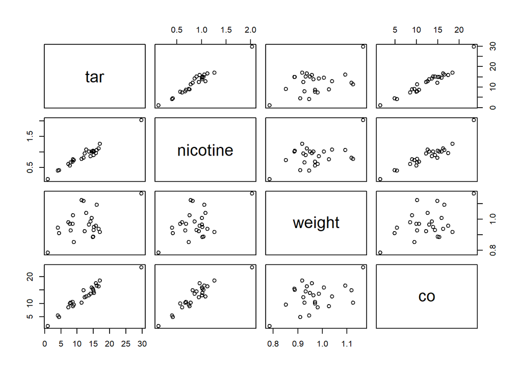

```r
pairs(cigs[,2:5])
```

We can also use the library `lattice` to create the scatterplots.

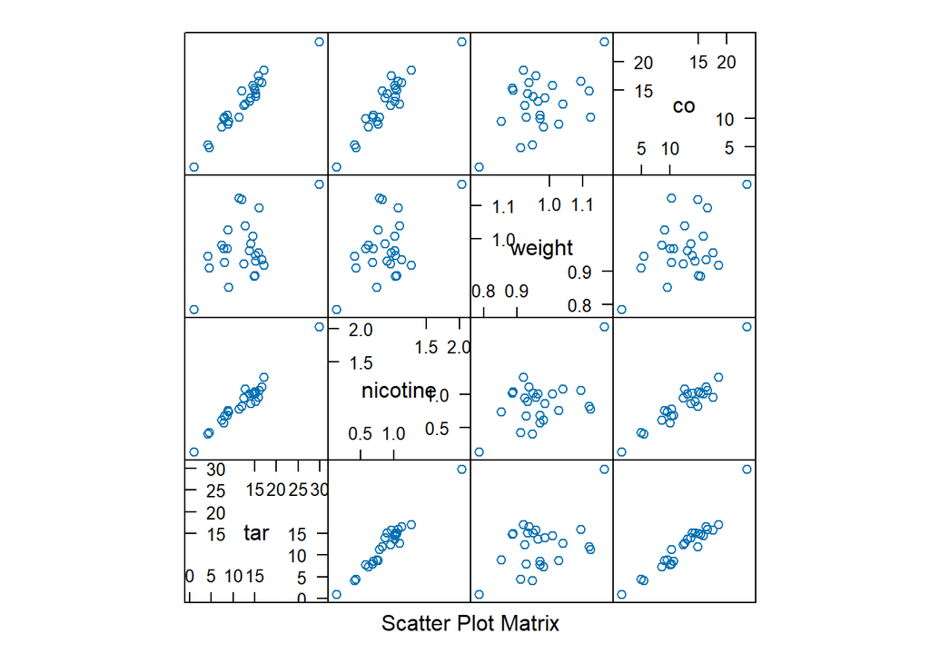

```r
#Putting "lattice::" before the function name just directly references which package the function is a part of
lattice::splom(cigs[,2:5])
```

Suppose we were to construct a model with all variables for CO output.

```r
#construct the model
cig_mod <- lm(co ~ tar + nicotine + weight, data = cigs)

#output coefficients
coef(cig_mod)
```

```
(Intercept)         tar    nicotine      weight
  3.2021900   0.9625739  -2.6316611  -0.1304819
```

We then evaluate the model:

```r
#remember both the F and t-test results are included in this output
summary(cig_mod)
```

```
Call:
lm(formula = co ~ tar + nicotine + weight, data = cigs)

Residuals:
     Min       1Q   Median       3Q      Max
-2.89261 -0.78269  0.00428  0.92891  2.45082

Coefficients:
            Estimate Std. Error t value Pr(>|t|)
(Intercept)   3.2022     3.4618   0.925 0.365464
tar           0.9626     0.2422   3.974 0.000692 ***
nicotine     -2.6317     3.9006  -0.675 0.507234
weight       -0.1305     3.8853  -0.034 0.973527
---
Signif. codes:  0 '***' 0.001 '**' 0.01 '*' 0.05 '.' 0.1 ' ' 1

Residual standard error: 1.446 on 21 degrees of freedom
Multiple R-squared:  0.9186,    Adjusted R-squared:  0.907
F-statistic: 78.98 on 3 and 21 DF,  p-value: 1.329e-11
```

Despite the strong relationship between Nicotine and CO, we do not find the variable to be a statistically significant predictor given the other variables in the model.

Why is this?

Let’s observe the the Variance Inflation Factor associated with our model. You will need the package `car` to calculate the VIF

```r
#vif function comes from the "car" package that we loaded at the top
vif(cig_mod)
```

```
      tar  nicotine    weight
21.630706 21.899917  1.333859
```

```r
vif(cig_mod) > 10
```

```
     tar nicotine   weight
    TRUE     TRUE    FALSE
```

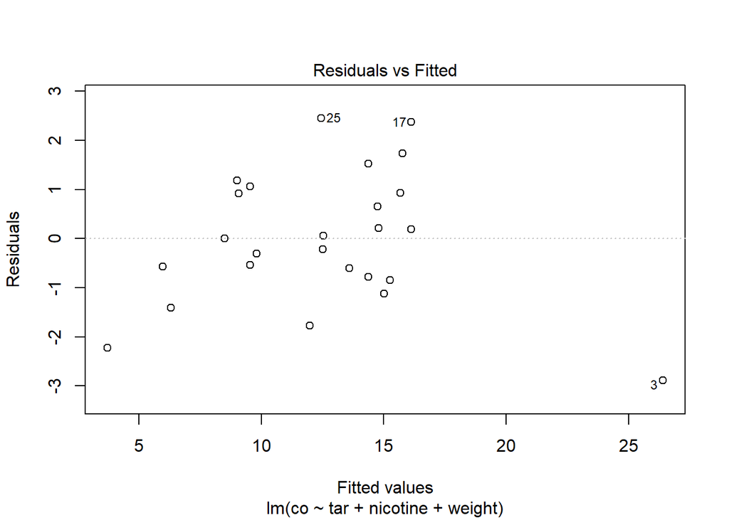

```r
#create diagnostic plots for assumptions
plot(cig_mod, 1, add.smooth = FALSE)
```

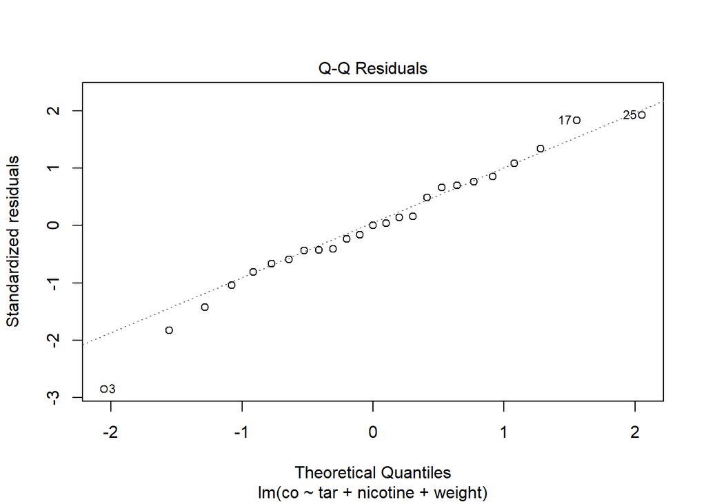

```r
plot(cig_mod, 2)
```

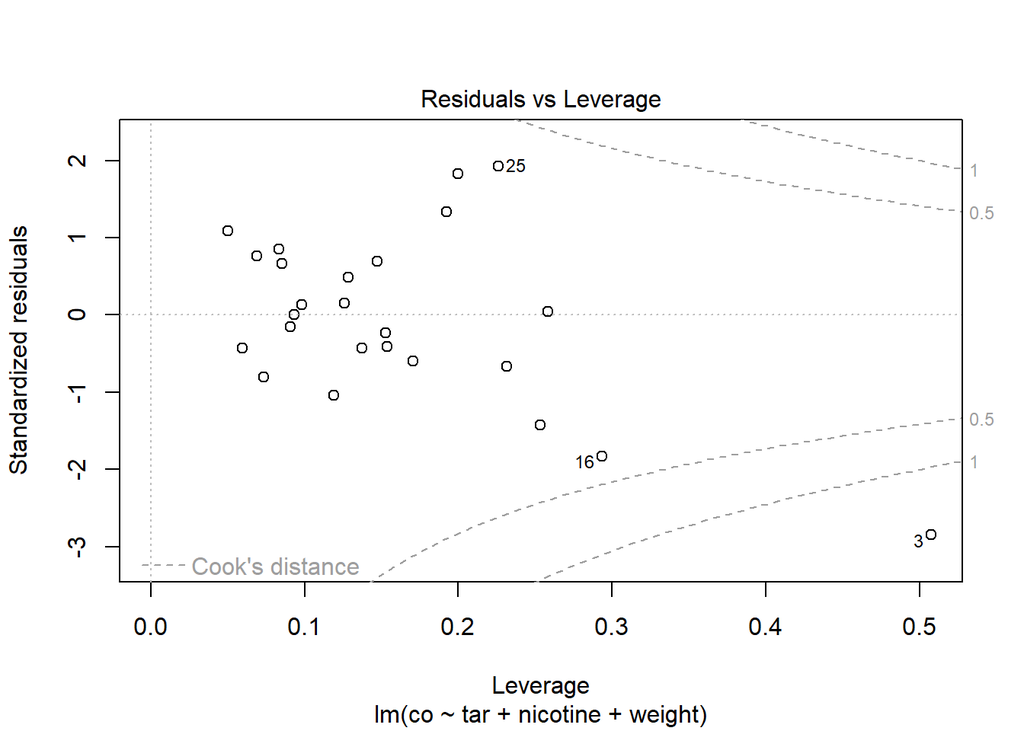

```r
plot(cig_mod, 5, add.smooth = FALSE)
```

Notice that Tar and Nicotine both have a very high VIF associated with them, indicating that they are most likely collinear. Here is how the VIF is calculated

```r
#CO is not involved, find the R^2 associated with a model for Nicotine
nic_mod <- lm(nicotine ~ weight + tar, data = cigs)

#extracts the NOT adjusted R^2
(nicr_2 <- summary(nic_mod)$r.squared)
```

```
[1] 0.9543377
```

```r
#calculates the VIF for nicotine
nic_vif <- 1/(1 - nicr_2)
nic_vif
```

```
[1] 21.89992
```

So we cannot include both Nicotine and Tar in our model - how do we choose which to include? Based on the model output, which model would you choose?

```r
#linear model including nicotine
cig_mod_nic <- lm(co ~ nicotine + weight, data = cigs)
summary(cig_mod_nic)
```

```
Call:
lm(formula = co ~ nicotine + weight, data = cigs)

Residuals:
    Min      1Q  Median      3Q     Max
-3.3304 -1.2249  0.2314  1.2677  3.9371

Coefficients:
            Estimate Std. Error t value Pr(>|t|)
(Intercept)  1.61398    4.44663   0.363    0.720
nicotine    12.38812    1.24473   9.952 1.32e-09 ***
weight       0.05883    5.02395   0.012    0.991
---
Signif. codes:  0 '***' 0.001 '**' 0.01 '*' 0.05 '.' 0.1 ' ' 1

Residual standard error: 1.87 on 22 degrees of freedom
Multiple R-squared:  0.8574,    Adjusted R-squared:  0.8444
F-statistic: 66.13 on 2 and 22 DF,  p-value: 4.966e-10
```

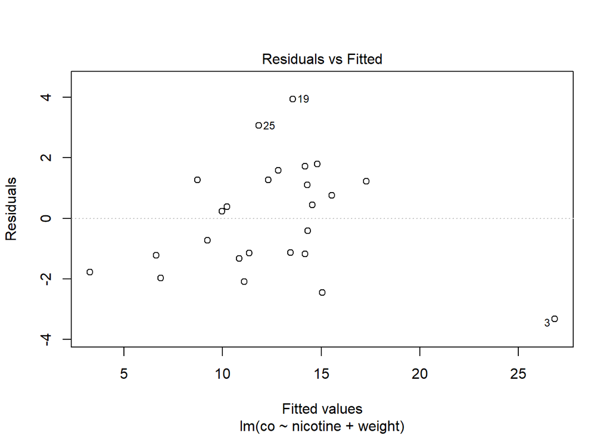

```r
#diagnostic plots
plot(cig_mod_nic, 1, add.smooth = FALSE)
```

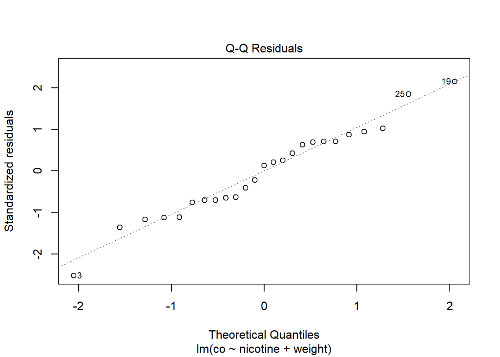

```r
plot(cig_mod_nic, 2)
```

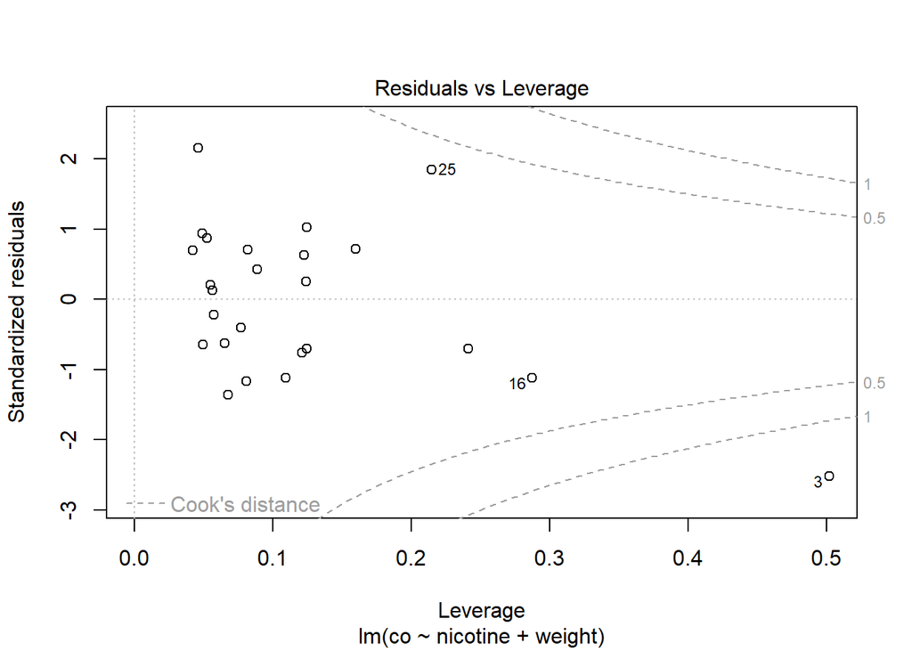

```r
plot(cig_mod_nic, 5, add.smooth = FALSE)
```

```r
#linear model including tar
cig_mod_tar <- lm(co ~ tar + weight, data = cigs)
summary(cig_mod_tar)
```

```
Call:
lm(formula = co ~ tar + weight, data = cigs)

Residuals:
    Min      1Q  Median      3Q     Max
-3.0865 -0.7239 -0.3684  1.0234  2.6083

Coefficients:
            Estimate Std. Error t value Pr(>|t|)
(Intercept)  3.11433    3.41620   0.912    0.372
tar          0.80419    0.05904  13.622 3.36e-12 ***
weight      -0.42287    3.81299  -0.111    0.913
---
Signif. codes:  0 '***' 0.001 '**' 0.01 '*' 0.05 '.' 0.1 ' ' 1

Residual standard error: 1.428 on 22 degrees of freedom
Multiple R-squared:  0.9168,    Adjusted R-squared:  0.9093
F-statistic: 121.3 on 2 and 22 DF,  p-value: 1.318e-12
```

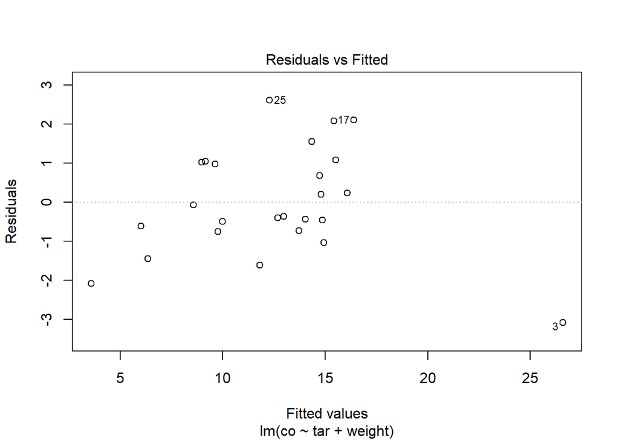

```r
#diagnostic plots
plot(cig_mod_tar, 1, add.smooth = FALSE)
```

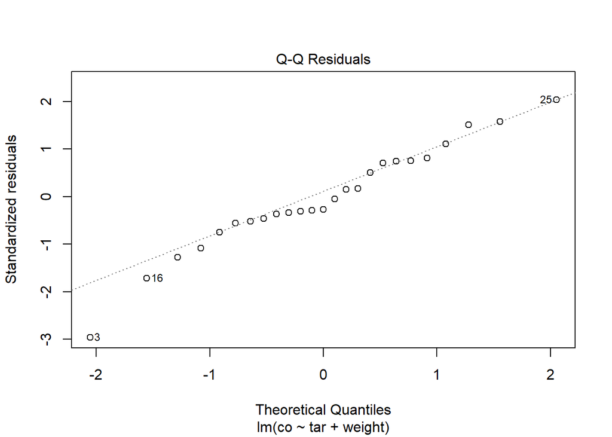

```r
plot(cig_mod_tar, 2)
```

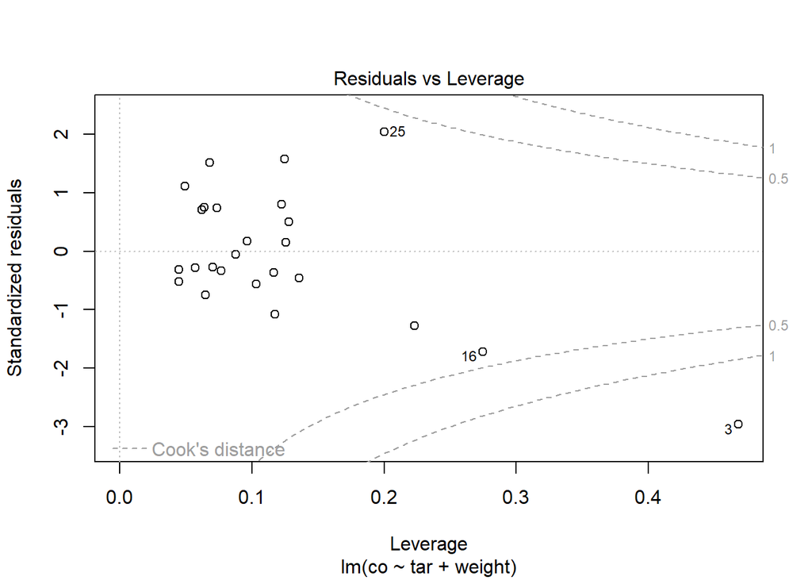

```r
plot(cig_mod_tar, 5, add.smooth = FALSE)
```

## Height and Weight by Sex

Let’s observed how we might include a categorical variable in our model.

```r
data(Davis) #found in the car package

#clean names
davis <- Davis |>
  clean_names()

#Just view the first couple of rows of data
head(davis)
```

```
  sex weight height repwt repht
1   M     77    182    77   180
2   F     58    161    51   159
3   F     53    161    54   158
4   M     68    177    70   175
5   F     59    157    59   155
6   M     76    170    76   165
```

```r
#variable information
str(davis)
```

```
'data.frame':   200 obs. of  5 variables:
 $ sex   : Factor w/ 2 levels "F","M": 2 1 1 2 1 2 2 2 2 2 ...
 $ weight: int  77 58 53 68 59 76 76 69 71 65 ...
 $ height: int  182 161 161 177 157 170 167 186 178 171 ...
 $ repwt : int  77 51 54 70 59 76 77 73 71 64 ...
 $ repht : int  180 159 158 175 155 165 165 180 175 170 ...
```

We can observe the relationship between height and weight for the students using a plot, but does that provide all the information we need? Also, what do you notice from the plot?

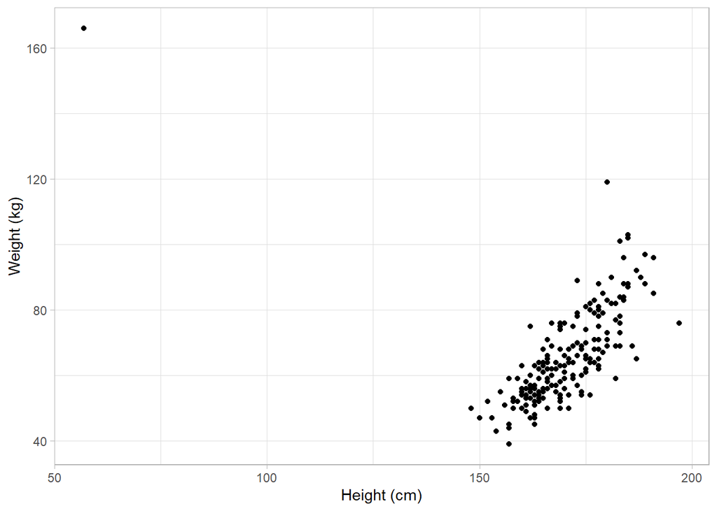

```r
#not including sex in the model
gf_point(weight ~ height, data = davis,
         xlab = "Height (cm)", ylab = "Weight (kg)")
```

There is an obvious outlier and after some investigation, we see it is row 12. Therefore, we want to remove that data point from our analysis (this is most likely a data entry error as there would not be someone who is less than 60 cm in real life, or at least not an adult).

```r
new_davis <- davis[-12,] #removes row 12 from the dataframe

new_davis <- davis |> #tidyverse method for removing outliers
  filter(height > 60)
```

Let’s use some new arguments in `ggformula` to look at our data, but split by sex.

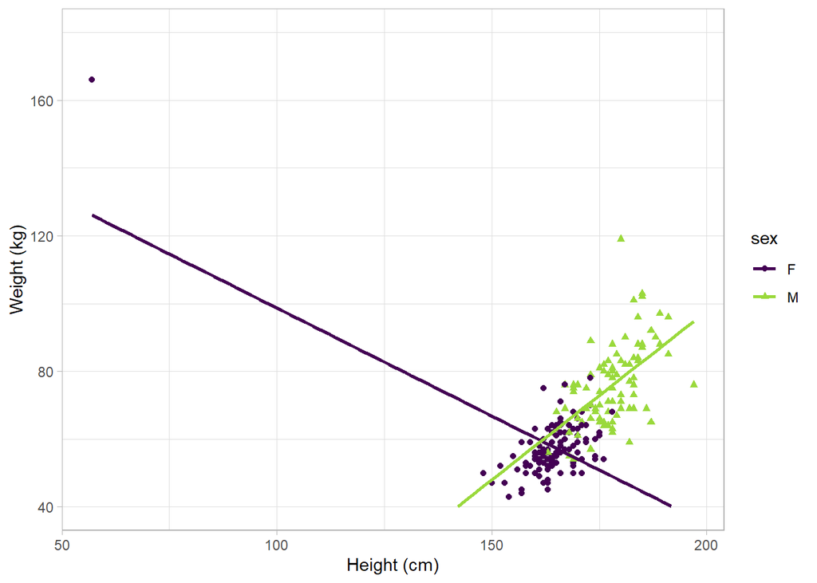

```r
#including sex in the model, WITH outlier
gf_point(weight ~ height, data = davis,
         shape = ~sex, color = ~sex,
         xlab = "Height (cm)", ylab = "Weight (kg)") |>
  gf_lm(size = 1) +
  ylim(40,180) +
  scale_color_viridis_d(end = 0.85)
```

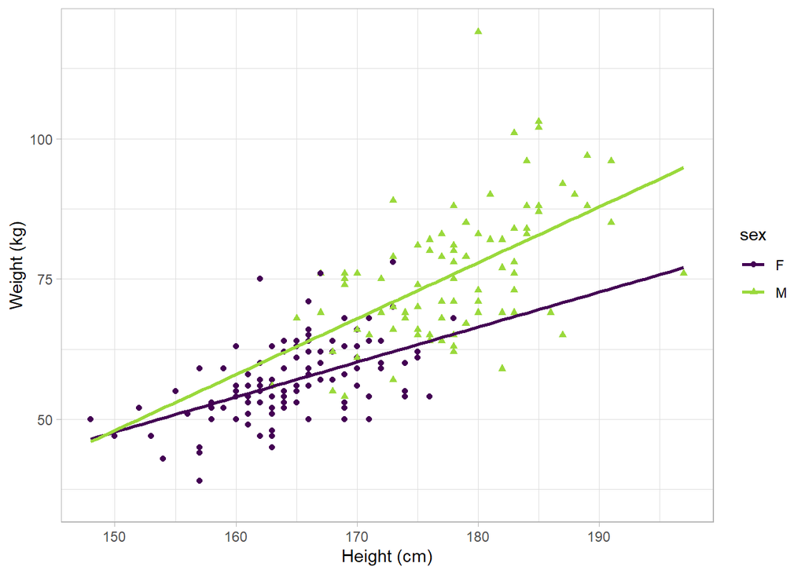

```r
#including sex in the model, outlier removed
gf_point(weight ~ height, data = new_davis,
         shape = ~sex, color = ~sex,
         xlab = "Height (cm)", ylab = "Weight (kg)") |>
  #linear model graph uses parameters from gf_point: 2 separate lines
  gf_lm(size = 1) +
  scale_color_viridis_d(end = 0.85)
```

By default, the above code treats the lines for each sex independently. We can force the lines to have identical slopes with the code below:

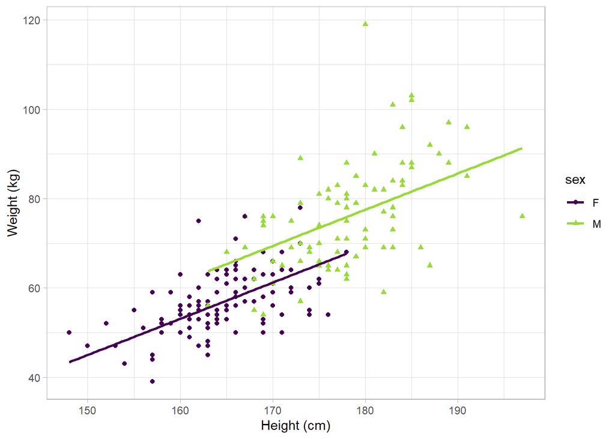

```r
gf_point(weight ~ height, data = new_davis,
         shape = ~sex, color = ~sex,
         xlab = "Height (cm)", ylab = "Weight (kg)") +
  #geom_parallel_slopes comes from moderndive package
  geom_parallel_slopes(se = FALSE) +
  scale_color_viridis_d(end = 0.85)
```

Here are the model coefficients

```r
#factor tells R to treat the "sex" variable as categorical
#Run the model, view coefficients and hypothesis tests
model_hws <- lm(weight ~ height + factor(sex), data = new_davis)
coef(model_hws)
```

```
 (Intercept)       height factor(sex)M
 -76.6362029    0.8107219    8.2162120
```

Hypohtesis Testing

```r
#hypothesis tests, coefficients, and VIF calculations
summary(model_hws)
```

```
Call:
lm(formula = weight ~ height + factor(sex), data = new_davis)

Residuals:
    Min      1Q  Median      3Q     Max
-20.131  -4.889  -0.404   5.205  41.490

Coefficients:
              Estimate Std. Error t value Pr(>|t|)
(Intercept)  -76.63620   15.75543  -4.864 2.36e-06 ***
height         0.81072    0.09555   8.485 5.24e-15 ***
factor(sex)M   8.21621    1.71726   4.784 3.37e-06 ***
---
Signif. codes:  0 '***' 0.001 '**' 0.01 '*' 0.05 '.' 0.1 ' ' 1

Residual standard error: 8.086 on 196 degrees of freedom
Multiple R-squared:  0.6365,    Adjusted R-squared:  0.6328
F-statistic: 171.6 on 2 and 196 DF,  p-value: < 2.2e-16
```

```r
vif(model_hws)
```

```
     height factor(sex)
   2.213881    2.213881
```

What are the additional assumptions we are making to construct a model with a qualitative variable?

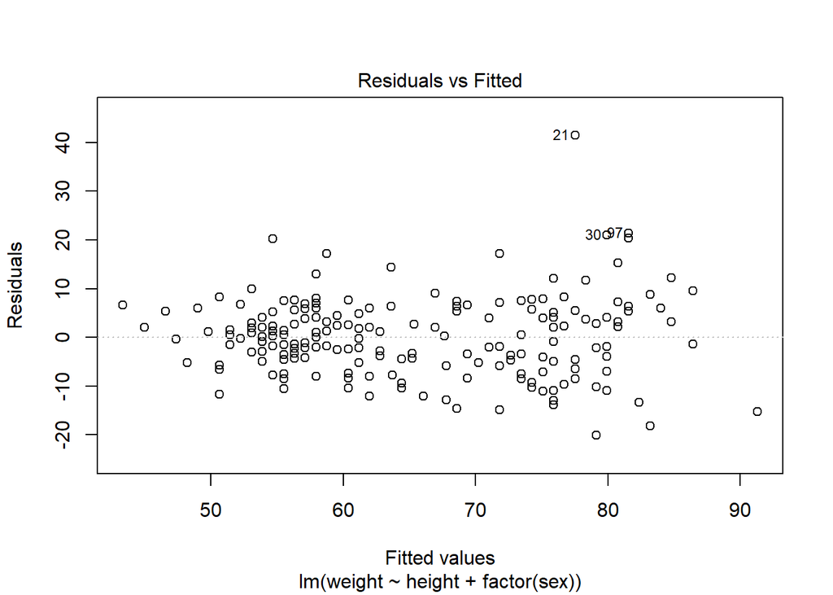

```r
#diagnostic plots for the hws model
plot(model_hws, 1, add.smooth = FALSE)
```

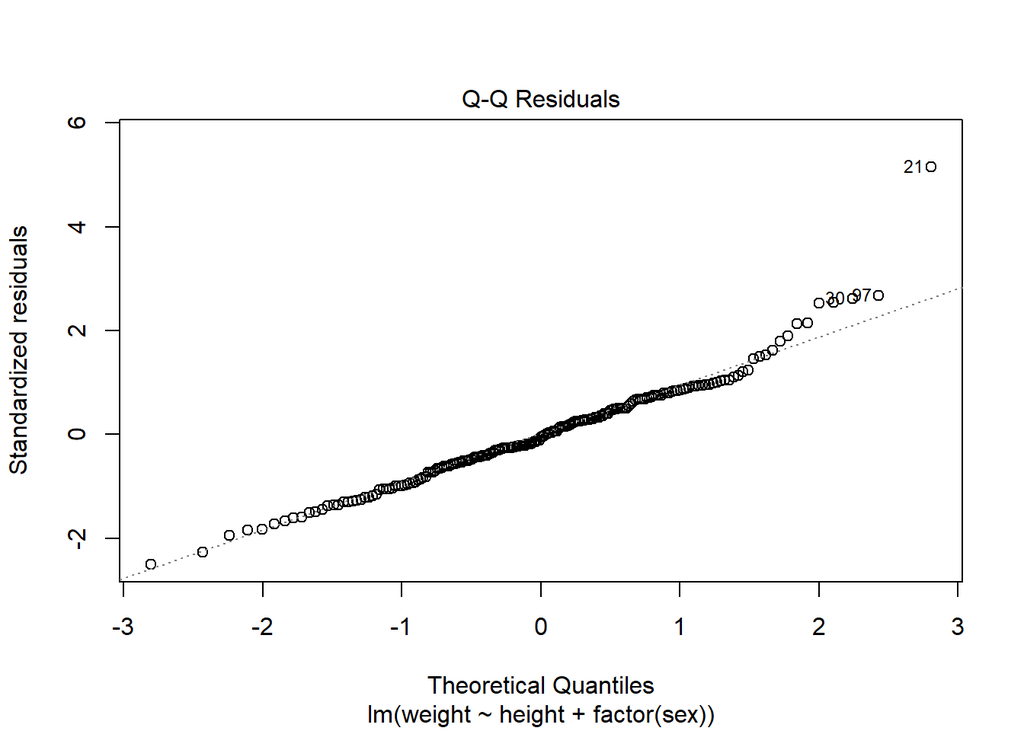

```r
plot(model_hws, 2)
```

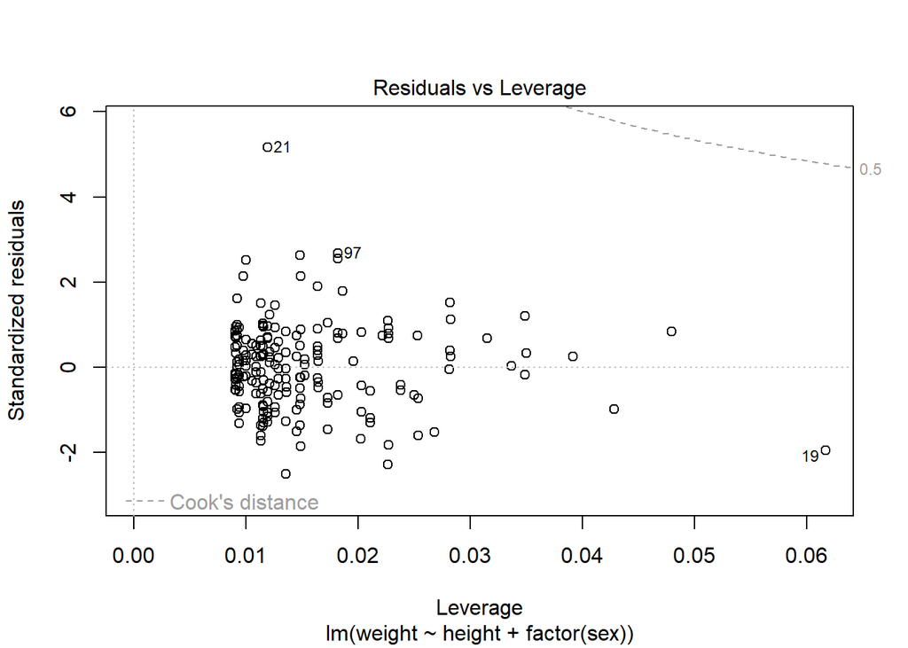

```r
plot(model_hws, 5, add.smooth = FALSE)
```

```r
#factor tells R to treat the "sex" variable as categorical
#Run the model, view coefficients and hypothesis tests
model_w_hs_int <- lm(weight ~ height*factor(sex), data = new_davis)
coef(model_w_hs_int)
```

```
        (Intercept)              height        factor(sex)M height:factor(sex)M
        -45.7084157           0.6229425         -55.6216345           0.3726556
```

```r
#hypothesis tests and coefficients for interaction model
summary(model_w_hs_int)
```

```
Call:
lm(formula = weight ~ height * factor(sex), data = new_davis)

Residuals:
    Min      1Q  Median      3Q     Max
-20.869  -4.848  -0.908   4.546  41.122

Coefficients:
                    Estimate Std. Error t value Pr(>|t|)
(Intercept)         -45.7084    22.1942  -2.059   0.0408 *
height                0.6229     0.1347   4.626  6.8e-06 ***
factor(sex)M        -55.6216    32.5447  -1.709   0.0890 .
height:factor(sex)M   0.3727     0.1897   1.964   0.0509 .
---
Signif. codes:  0 '***' 0.001 '**' 0.01 '*' 0.05 '.' 0.1 ' ' 1

Residual standard error: 8.028 on 195 degrees of freedom
Multiple R-squared:  0.6435,    Adjusted R-squared:  0.6381
F-statistic: 117.3 on 3 and 195 DF,  p-value: < 2.2e-16
```

```r
#vif calculations
vif(model_w_hs_int)
```

```
            height        factor(sex) height:factor(sex)
          4.462529         806.730224         870.754630
```

What are the additional assumptions we are making to construct a model with a qualitative variable?

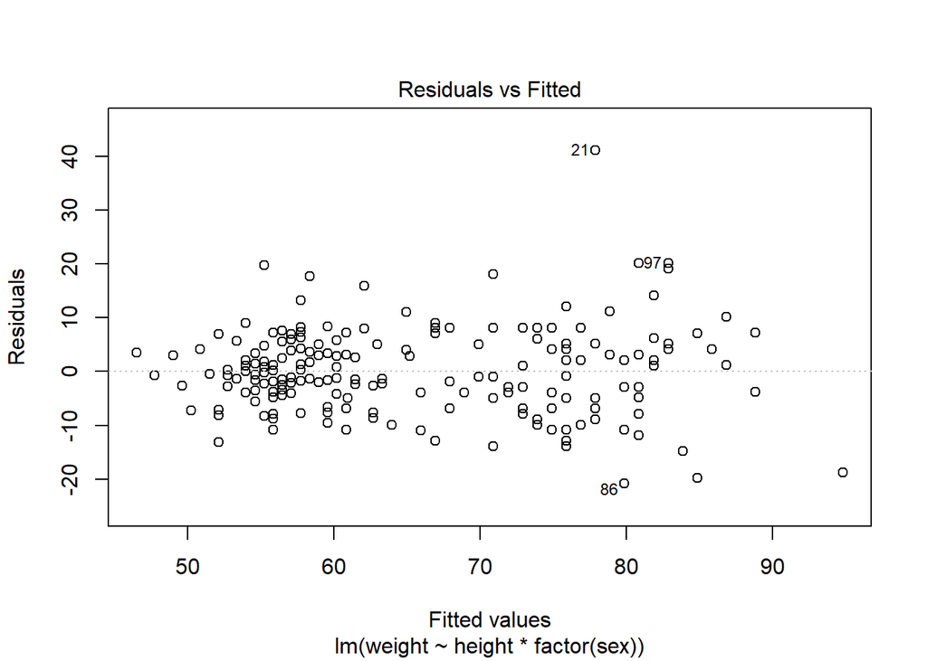

```r
#diagnostic plots for interaction model
plot(model_w_hs_int, 1, add.smooth = FALSE)
```

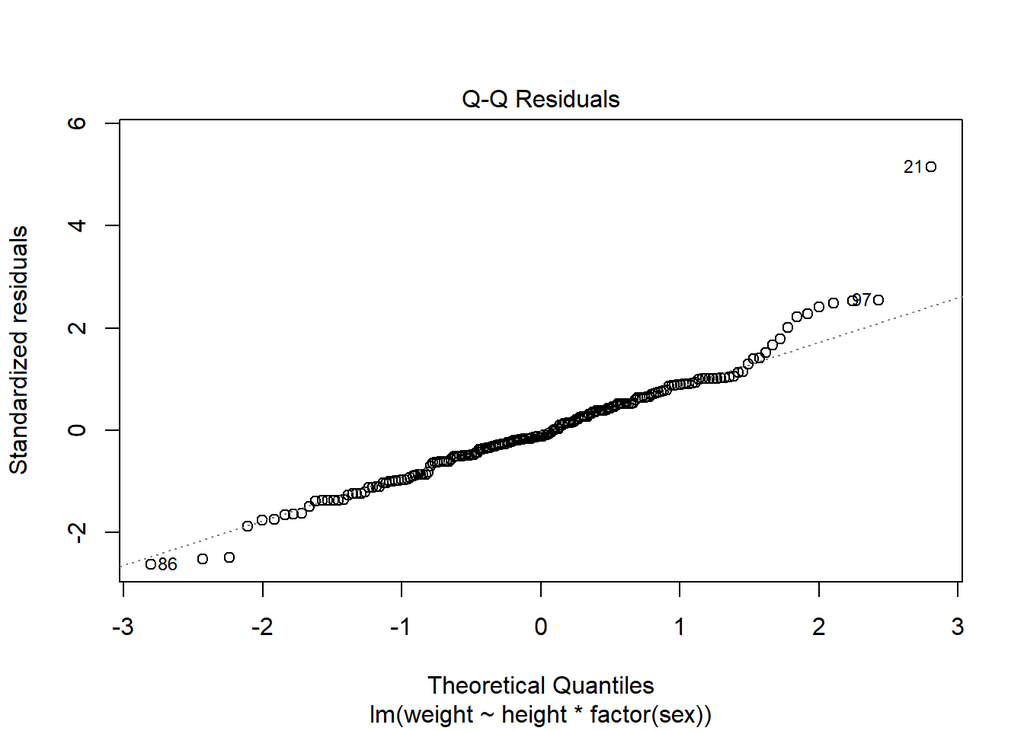

```r
plot(model_w_hs_int, 2)
```

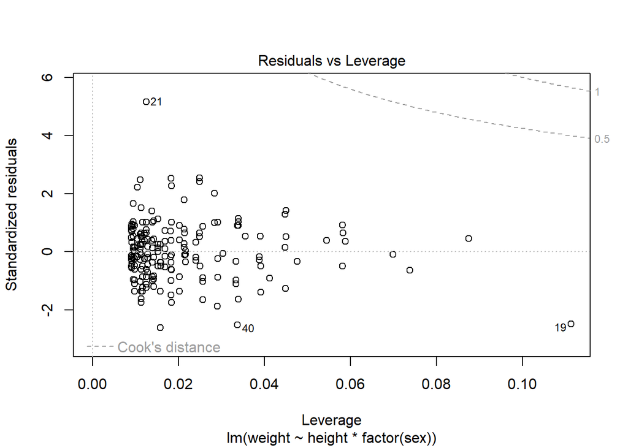

```r
plot(model_w_hs_int, 5, add.smooth = FALSE)
```